# Examen 1, Métodos análiticos

Entrega tus resultados y el código que utilizaste.

# Parte 1: correos de Enron, similitud y minhashing.

En este ejemplo construiremos uan aplicación para devolver rápidamente correos similares a uno dado, en el sentido de que contienen palabras similares. Utilizaremos minhashing/LSH.

Utilizaremos los datos de correo de Enron de https://archive.ics.uci.edu/ml/datasets/Bag+of+Words

El formato está explicado en el archivo que acompaña los datos:

he format of the docword.*.txt file is 3 header lines, followed by NNZ triples: — D W NNZ docID wordID count docID wordID count docID wordID count docID wordID count … docID wordID count docID wordID count docID wordID count —

### Enron (bag of words)

```r
# lectura de datos
library(dplyr)
library(Rcpp)
enron <- read.table('enron/docword.enron.txt', skip=3, header=FALSE, sep=' ')
names(enron) <- c('doc','word_id','n')
head(enron)
```

```
##   doc word_id n
## 1   1     118 1
## 2   1     285 1
## 3   1    1229 1
## 4   1    1688 1
## 5   1    2068 1
## 6   1    5299 1
```

```r
length(unique(enron$word_id))
```

```
## [1] 28099
```

```r
length(unique(enron$doc))
```

```
## [1] 39861
```

```r
vocab <- read.table('enron/vocab.enron.txt', header=FALSE)
vocab$word_id <- 1:nrow(vocab)
names(vocab) <- c("word", "word_id")
```

Usaremos **similitud de jaccard** basada en el modelo *bag of words* para documentos, es decir, sólo en función de las palabras que contienen: la similitud entre el documento A y B es el número de palabras en común dividido entre el número total de palabras que ocurren en los dos documentos. Aquí hay una implementación simple:

```r
jaccard <- function(doc1, doc2){
  a <- length(union(doc1$word_id, doc2$word_id))
  c <- length(intersect(doc1$word_id, doc2$word_id))
  c/a # y las repetidas? sets...
}
jaccard(filter(enron, doc==1), filter(enron, doc==2))
```

```
## [1] 0.02631579
```

```r
jaccard(filter(enron, doc==1), filter(enron, doc==8000))
```

```
## [1] 0
```

## Minhashing

Construye una matriz de firmas de minhashing para esta colección. Utiliza la matriz de firmas para encontrar mails similares al 900 (más de 50% de similitud de Jaccard) ¿Qué palabras comparten estos documentos?

Necesitamos generar $m$ funciones hash tales que $h_i(x) = (ax + b mod p) mod k$

donde $k$ es el número de tejas posibles, $p$ un primo tal que $p > k > 0$, $a,b$ escogidos al azar donde $0<a$ y $a,b<p$.

```r
# # Mi funcion
# set.seed(2805)
# m <- 200 # numero de funciones hash
# hash.lista <- lapply(1:m, function(i){
#     p <- 29167# primo > 28099 (numero de tejas)
#     a <- sample(1:(p-1), 1) # 0<a<p
#     b <- sample(1:(p-1), 1) # 0<b<p
#     function(x){
#         (((a*(x-1) + b) %% p) %% 28099) + 1
#     }
# })

# La de la ayuda...
set.seed(2805)
hash.lista <- lapply(1:200, function(i){
    primo <- length(unique(enron$word_id))
    a <- sample(1:(primo-1), 1)
    b <- sample(1:(primo-1), 1)
    function(x){
        ((a*(x-1) + b) %% primo)  + 1
    }
})
```

Utilizaremos el algoritmo por renglón para poder calcular la matriz de firmas.

Para este debemos seguir los siguientes pasos:

1. Definimos la matriz de firmas como $sig(i,c)=inf$.
2. Ciclamos
   - Para cada renglón $r$ (*teja*):
     - Para cada documento $c$ (*columna*):
       - Si $c$ tiene un 1 en el renglón $r$, entonces para cada función hash $h_i$, si $h_i(r)$ es menor a $sig(i,c)$, entonces $sig(i,c)=h_i(r)$.

Al final del algoritmo, $sig$ es la matriz de firmas de los documentos bajo las funciones hash $h_1,...,h_m$.

Implementamos el algoritmo de tal forma que aprovechemos que la matriz de tejas documentos ya está calculada en *enron*.

```r
# Jalamos funcion auxiliar
sourceCpp('src/update_mat.cpp')

minhash <- function(matriz, hashes){
    r <- length(unique(enron$word_id))  # numero de palabras
    c <- length(unique(enron$doc)) # numero de documentos
    m <- length(hashes) # numero de hashes
    sig <- matrix(rep(Inf, m*c), ncol=c) # Paso 1 algoritmo
    for(i in 1:r){ # Paso 2: iteramos en renglones
        renglon <- sapply(hashes, function(hash){hash(i)})# Aplicamos todos los hashes a cada palabra en el vocabulario
        docs <- enron$doc[which(enron$word_id==i)]# Extraemos todos los docs con esa palabra
        out <- sapply(docs,function(doc){update_mat(sig, doc, renglon)})# Updateamos la matriz de firmas iterando sobre los docs que tienen esa palabra
    }
    sig
}

firmas <- minhash(enron, hash.lista)
save(firmas, file='./output/firmas.Rdata')
```

Par de sanity checks.

```r
load('output/firmas.Rdata')
dim(firmas)
```

```
## [1]   200 39861
```

```r
firmas[1:6,1:6]
```

```
##      [,1] [,2] [,3] [,4] [,5] [,6]
## [1,]  614  380   93  537 1669  494
## [2,]  131  238    6  277  226  406
## [3,]  392  140  564 1060  381 1152
## [4,]  621   55  935  217  169 2497
## [5,]  691   27  221  307  208   14
## [6,]  408  262   45 1019  675  420
```

Una vez calculada la matriz de firmas, encontramos los mails más parecidos al 900 con similitud de jaccard mayor al 50%.

```r
doc <- 900
# Lo vemos
words <- left_join(filter(enron, doc==900),vocab)$word #correo grosero!
words
```

```
##  [1] address     balance     bill        code        consolidate
##  [6] cost        credit      creditor    debt        end
## [11] equity      estimated   form        free        fuck
## [16] full        help        helped      hit         home
## [21] improve     incurred    interested  invite      late
## [26] loan        low         lower       message     mind
## [31] month       monthly     obligation  party       payment
## [36] phone       principal   program     property    provide
## [41] provided    rating      read        reduce      remove
## [46] reply       request     risk        securely    send
## [51] size        sources     stop        thing       thousand
## [56] totally     unsubscribe zip
## 28102 Levels: aaa aaas aactive aadvantage aaker aap aapg aaron aarp ... zycher
```

```r
# extraemos sus firmas
doc.firma <- firmas[,doc]
# sacamos similitudes aproximadas
sim_est <- apply(firmas, 2, function(x){mean(x==doc.firma)})
# sacamos docs con similitud mayor a 50%
docs.sim <- which(sim_est>=0.5)

# palabras compartidas
lapply(docs.sim[-1], FUN=function(x){union(left_join(filter(enron, doc==900),vocab)$word, left_join(filter(enron, doc==x),vocab)$word)})
```

```
## [[1]]
##  [1] "address"     "balance"     "bill"        "code"        "consolidate"
##  [6] "cost"        "credit"      "creditor"    "debt"        "end"
## [11] "equity"      "estimated"   "form"        "free"        "fuck"
## [16] "full"        "help"        "helped"      "hit"         "home"
## [21] "improve"     "incurred"    "interested"  "invite"      "late"
## [26] "loan"        "low"         "lower"       "message"     "mind"
## [31] "month"       "monthly"     "obligation"  "party"       "payment"
## [36] "phone"       "principal"   "program"     "property"    "provide"
## [41] "provided"    "rating"      "read"        "reduce"      "remove"
## [46] "reply"       "request"     "risk"        "securely"    "send"
## [51] "size"        "sources"     "stop"        "thing"       "thousand"
## [56] "totally"     "unsubscribe" "zip"
##
## [[2]]
```

[output cut: 56 more lines]

## LSH

Utiliza 8 bandas de 2 hashes cada una para obtener pares candidatos para similitud. Devuelve los 20 mejores candidatos (si existen) para los documentos 100, 105,1400. Recuerda calcular la similitud exacta para los pares candidatos que consideres.

En el gráfico siguiente, se observa la probabilidad de que al menos coincida una banda de minhashes en función de la similitud.

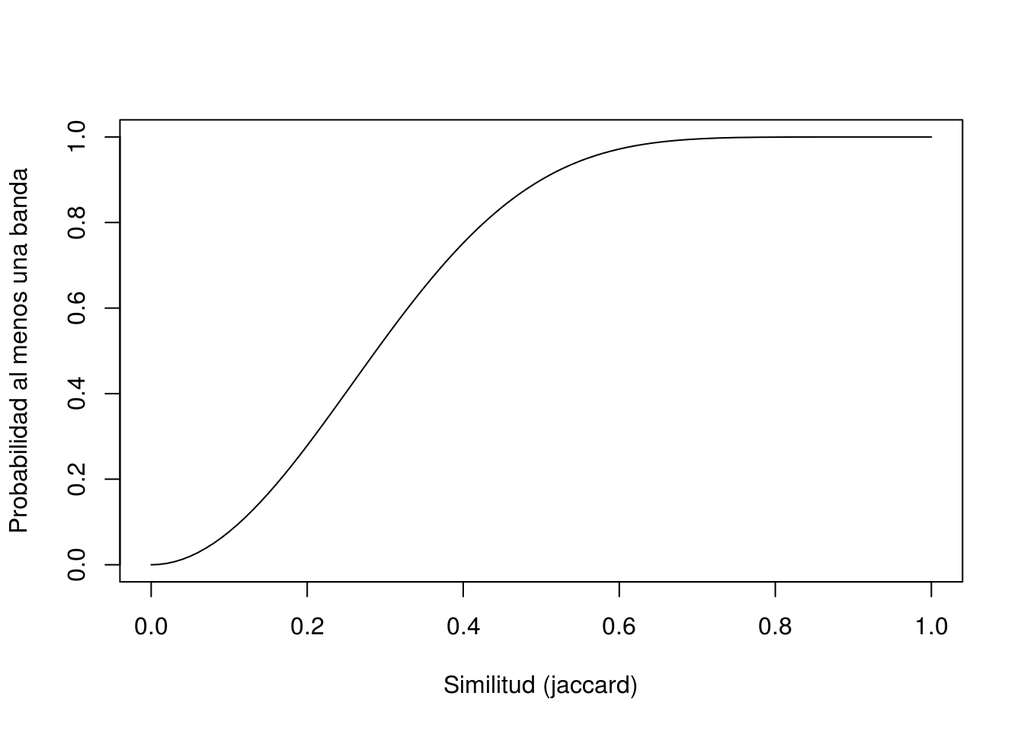

```r
r=2
b=8
plot(s <- seq(0, 1, by = 0.01), 1 - (1 - s^r)^b, type = "l", ylab = "Probabilidad al menos una banda",
     xlab = "Similitud (jaccard)")
```

Ahora dividimos la matriz de firmas en 8 bandas de 2 hashes cada uno. Después, calculamos un nuevo hash para extraer pares candidatos. Obtenemos una matriz de dimensión documentos por hashes.

```r
mat.split <- split(data.frame((firmas)), rep(1:8, each=2))

# Agarro la firma y la sumo - asi tal cual! Ese es mi hash ahora. Obviamente, con la suma hay falsos positivos pero es muy eficiente. Si la suma es igual, digo que son paress candidatos (es decir, que caen en "la misma cubeta")
mat.hashed <- sapply(mat.split, function(mat){
    apply(mat, 2, function(x){   sum(x) })
})
dim(mat.hashed) # documentos x (hashes de la banda)
```

```
## [1] 39861     8
```

```r
# Le agregamos el numero del documento
mat.hashed <- data.frame(mat.hashed)
mat.hashed$doc_no <- 1:nrow(mat.hashed)
```

```r
# Calculamos pares candidatos
candidatos <- lapply(1:8, function(i){ #para cada banda
    tab.1 <- table(mat.hashed[,i]) # extraemos el hash de la banda i
    codigos <- as.integer(names(tab.1[tab.1 >= 2]))
   salida <- lapply(codigos, function(cod){
        mat.hashed$doc_no[mat.hashed[,i] == cod]
    })
   Reduce('cbind',lapply(salida, function(i){combn(i,2)}))
})
candidatos.tot <- t(Reduce('cbind',candidatos))
head(candidatos.tot)
```

```
##       [,1]  [,2]
## [1,] 31631 34034
## [2,] 30426 34051
## [3,] 27774 34015
## [4,] 30671 33962
## [5,] 27995 30628
## [6,] 27995 33562
```

```r
# Dimension de los candidatos calculados
dim(candidatos.tot)
```

```
## [1] 499298      2
```

```r
candidatos.tot.2 <- unique(candidatos.tot)
dim(candidatos.tot.2)
```

```
## [1] 193487      2
```

```r
save(candidatos.tot.2, candidatos.tot, file="output/candidatos.Rdata")
```

Los pares candidatos son 193487 y están guardados en *candidatos.tot.2*. Ahora debemos calcular la similitud exacta para cada uno de esos pares para eliminar falsos positivos.

Como vemos, son muchos los pares candidatos. Nos quedamos únicamente con los de interes y eliminamos de la matriz filtrada la coicidencia consigo mismo.

```r
load('./output/candidatos.Rdata')
# Nos quedamos los pares candidatos que incluyen los de interes
interes <- c(100,105,1400)
todos <- as.data.frame(candidatos.tot.2)
docs.interes <- todos[which(todos$V1 %in% interes | todos$V2 %in% interes),] %>% arrange(V1)

# Calculamos Jaccard exacto pa los candidatos
docs.interes$jaccard <- apply(docs.interes, MARGIN=1, FUN=function(x){
    jaccard(filter(enron, doc==x[1]), filter(enron, doc==x[2]))
})


#
por.doc <- lapply(interes, function(x){filter(docs.interes, V1==x | V2==x)})
# Los primeros 20 documentos similares, en orden son
lapply(por.doc, function(df){
    simil <- df %>% arrange(-jaccard) %>% select(V2)
    simil[!is.na(simil[1:20,]),]
})
```

```
## [[1]]
## [1] 34002 21929 17995  9990 14946
##
## [[2]]
## [1]  3091 38828 31411 10110 18172 15252 18289  7673  1235
##
## [[3]]
##  [1] 20981 20809 12588 11405 37910 17432 31247 31089 36487 14066 23286
```

## LSH

Describe la distribución de palabras para cada uno de los tres clusters que encontraste en el inciso anterior. Describe los clusters en términos de las palabras más comunes. Utiliza código como el siguiente:

```r
docs.similares <- lapply(por.doc, function(df){
    simil <- df %>% arrange(-jaccard) %>% select(V2)
    simil$V2
})

lapply(docs.similares, FUN=function(docs){filter(enron, doc %in% docs) %>% group_by(word_id) %>%
  summarise(n_tot= sum(n)) %>% arrange(desc(n_tot)) %>% left_join(vocab)})
```

```
## [[1]]
## Source: local data frame [289 x 3]
##
##    word_id n_tot        word
## 1     8647     7      estate
## 2     4865     6     company
## 3     5463     5        corp
## 4     5299     4    contract
## 5    12247     4 immigration
## 6    19794     4    provided
## 7    23884     4      status
## 8       44     3     ability
## 9     2068     3       basis
## 10    5234     3  consulting
## ..     ...   ...         ...
##
## [[2]]
## Source: local data frame [327 x 3]
##
##    word_id n_tot         word
## 1    19117     8     position
## 2     4617     6         code
## 3    17245     5     november
## 4    19592     5      process
## 5    21289     5       review
## 6     5088     4 confirmation
## 7     8159     4          ena
## 8    22022     4     saturday
## 9    25092     4         text
## 10      46     3         able
## ..     ...   ...          ...
##
## [[3]]
## Source: local data frame [853 x 3]
##
##    word_id n_tot        word
## 1    22007    44         sat
## 2    14707    26      london
## 3    24379    25         sun
## 4    22123    16   scheduled
## 5    17859    15      outage
## 6    12254    14      impact
## 7    15617    14     meeting
## 8    17860    14     outages
## 9     8426    13 environment
## 10   12255    13    impacted
## ..     ...   ...         ...
```

Ayuda: puedes comenzar con el siguiente código si quieres

```r
set.seed(2805)
hash.lista <- lapply(1:200, function(i){
    primo <- 28099
    a <- sample(1:(primo-1), 1)
    b <- sample(1:(primo-1), 1)
    function(x){
        ((a*(x-1) + b) %% primo)  + 1
    }
})

minhash <- function(dat, hash.lista){
    n_words <- 28099
    n_docs <- 39861
    p <- length(hash.lista)
    sig <- matrix(rep(Inf, p*n_docs) , ncol = n_docs)
    for(i in 1:n_words){
      #######################################

      ##### puedes rellenar tu código aquí

      #######################################
    }
    sig
}
```